# 1 Prepare and analyse the dataset

1.1 Load the Wisconsin breast cancer data set from the scikit-learn sample data collection. Read the full documentation: https://scikit-learn.org/stable/datasets/index.html#breast-cancer-dataset.

[figure not shown]

Figure 1:This image shows an example image of a tissue sample obtained by fine needle aspiration. A more detailed description of the parameters can be found here: https://minds.wisconsin.edu/bitstream/1793/59692/1/TR1131.pdf

```python
# Importing modules required
from sklearn.datasets import load_breast_cancer
import pandas as pd
import numpy as np
import matplotlib.pyplot as plt
import seaborn as sns
from sklearn import metrics
from sklearn.metrics import roc_curve
from sklearn.model_selection import train_test_split
from sklearn.linear_model import SGDClassifier
from sklearn.preprocessing import StandardScaler
from sklearn.pipeline import make_pipeline
from sklearn.model_selection import GridSearchCV
from sklearn.metrics import confusion_matrix, ConfusionMatrixDisplay, precision_score, recall_score
import matplotlib.colors as mcolors
import matplotlib.patches as mpatches
sns.set_theme(style= 'whitegrid')
%matplotlib inline

# Loading in the dataset
breast_cancer = load_breast_cancer()
print("Classes prensent in data:", breast_cancer.target_names)
df =  pd.DataFrame(breast_cancer.data, columns=[breast_cancer.feature_names])
df['target'] = breast_cancer.target
print("Shape of data:", df.shape)
print("number of incomplete intances:", df.isna().values.ravel().sum())
df
```

```
Classes prensent in data: ['malignant' 'benign']
Shape of data: (569, 31)
number of incomplete intances: 0
```

|  | mean radius | mean texture | mean perimeter | mean area | mean smoothness | mean compactness | mean concavity | mean concave points | mean symmetry | mean fractal dimension | ... | worst texture | worst perimeter | worst area | worst smoothness | worst compactness | worst concavity | worst concave points | worst symmetry | worst fractal dimension | target |
| --- | --- | --- | --- | --- | --- | --- | --- | --- | --- | --- | --- | --- | --- | --- | --- | --- | --- | --- | --- | --- | --- |
| 0 | 17.99 | 10.38 | 122.80 | 1001.0 | 0.11840 | 0.27760 | 0.30010 | 0.14710 | 0.2419 | 0.07871 | ... | 17.33 | 184.60 | 2019.0 | 0.16220 | 0.66560 | 0.7119 | 0.2654 | 0.4601 | 0.11890 | 0 |
| 1 | 20.57 | 17.77 | 132.90 | 1326.0 | 0.08474 | 0.07864 | 0.08690 | 0.07017 | 0.1812 | 0.05667 | ... | 23.41 | 158.80 | 1956.0 | 0.12380 | 0.18660 | 0.2416 | 0.1860 | 0.2750 | 0.08902 | 0 |
| 2 | 19.69 | 21.25 | 130.00 | 1203.0 | 0.10960 | 0.15990 | 0.19740 | 0.12790 | 0.2069 | 0.05999 | ... | 25.53 | 152.50 | 1709.0 | 0.14440 | 0.42450 | 0.4504 | 0.2430 | 0.3613 | 0.08758 | 0 |
| 3 | 11.42 | 20.38 | 77.58 | 386.1 | 0.14250 | 0.28390 | 0.24140 | 0.10520 | 0.2597 | 0.09744 | ... | 26.50 | 98.87 | 567.7 | 0.20980 | 0.86630 | 0.6869 | 0.2575 | 0.6638 | 0.17300 | 0 |
| 4 | 20.29 | 14.34 | 135.10 | 1297.0 | 0.10030 | 0.13280 | 0.19800 | 0.10430 | 0.1809 | 0.05883 | ... | 16.67 | 152.20 | 1575.0 | 0.13740 | 0.20500 | 0.4000 | 0.1625 | 0.2364 | 0.07678 | 0 |
| ... | ... | ... | ... | ... | ... | ... | ... | ... | ... | ... | ... | ... | ... | ... | ... | ... | ... | ... | ... | ... | ... |
| 564 | 21.56 | 22.39 | 142.00 | 1479.0 | 0.11100 | 0.11590 | 0.24390 | 0.13890 | 0.1726 | 0.05623 | ... | 26.40 | 166.10 | 2027.0 | 0.14100 | 0.21130 | 0.4107 | 0.2216 | 0.2060 | 0.07115 | 0 |
| 565 | 20.13 | 28.25 | 131.20 | 1261.0 | 0.09780 | 0.10340 | 0.14400 | 0.09791 | 0.1752 | 0.05533 | ... | 38.25 | 155.00 | 1731.0 | 0.11660 | 0.19220 | 0.3215 | 0.1628 | 0.2572 | 0.06637 | 0 |
| 566 | 16.60 | 28.08 | 108.30 | 858.1 | 0.08455 | 0.10230 | 0.09251 | 0.05302 | 0.1590 | 0.05648 | ... | 34.12 | 126.70 | 1124.0 | 0.11390 | 0.30940 | 0.3403 | 0.1418 | 0.2218 | 0.07820 | 0 |
| 567 | 20.60 | 29.33 | 140.10 | 1265.0 | 0.11780 | 0.27700 | 0.35140 | 0.15200 | 0.2397 | 0.07016 | ... | 39.42 | 184.60 | 1821.0 | 0.16500 | 0.86810 | 0.9387 | 0.2650 | 0.4087 | 0.12400 | 0 |
| 568 | 7.76 | 24.54 | 47.92 | 181.0 | 0.05263 | 0.04362 | 0.00000 | 0.00000 | 0.1587 | 0.05884 | ... | 30.37 | 59.16 | 268.6 | 0.08996 | 0.06444 | 0.0000 | 0.0000 | 0.2871 | 0.07039 | 1 |

569 rows × 31 columns

1.2 Summarise the dataset with pandas functions `info()` and `describe()`.

```python
# Observing clenliness characteristics of the data
df.info()
```

```
<class 'pandas.core.frame.DataFrame'>
RangeIndex: 569 entries, 0 to 568
Data columns (total 31 columns):
 #   Column                      Non-Null Count  Dtype
---  ------                      --------------  -----
 0   (mean radius,)              569 non-null    float64
 1   (mean texture,)             569 non-null    float64
 2   (mean perimeter,)           569 non-null    float64
 3   (mean area,)                569 non-null    float64
 4   (mean smoothness,)          569 non-null    float64
 5   (mean compactness,)         569 non-null    float64
 6   (mean concavity,)           569 non-null    float64
 7   (mean concave points,)      569 non-null    float64
 8   (mean symmetry,)            569 non-null    float64
 9   (mean fractal dimension,)   569 non-null    float64
```

[output cut: 23 more lines]

```python
# Observing statistical characteristics of the data
df.describe()
```

|  | mean radius | mean texture | mean perimeter | mean area | mean smoothness | mean compactness | mean concavity | mean concave points | mean symmetry | mean fractal dimension | ... | worst texture | worst perimeter | worst area | worst smoothness | worst compactness | worst concavity | worst concave points | worst symmetry | worst fractal dimension | target |
| --- | --- | --- | --- | --- | --- | --- | --- | --- | --- | --- | --- | --- | --- | --- | --- | --- | --- | --- | --- | --- | --- |
| count | 569.000000 | 569.000000 | 569.000000 | 569.000000 | 569.000000 | 569.000000 | 569.000000 | 569.000000 | 569.000000 | 569.000000 | ... | 569.000000 | 569.000000 | 569.000000 | 569.000000 | 569.000000 | 569.000000 | 569.000000 | 569.000000 | 569.000000 | 569.000000 |
| mean | 14.127292 | 19.289649 | 91.969033 | 654.889104 | 0.096360 | 0.104341 | 0.088799 | 0.048919 | 0.181162 | 0.062798 | ... | 25.677223 | 107.261213 | 880.583128 | 0.132369 | 0.254265 | 0.272188 | 0.114606 | 0.290076 | 0.083946 | 0.627417 |
| std | 3.524049 | 4.301036 | 24.298981 | 351.914129 | 0.014064 | 0.052813 | 0.079720 | 0.038803 | 0.027414 | 0.007060 | ... | 6.146258 | 33.602542 | 569.356993 | 0.022832 | 0.157336 | 0.208624 | 0.065732 | 0.061867 | 0.018061 | 0.483918 |
| min | 6.981000 | 9.710000 | 43.790000 | 143.500000 | 0.052630 | 0.019380 | 0.000000 | 0.000000 | 0.106000 | 0.049960 | ... | 12.020000 | 50.410000 | 185.200000 | 0.071170 | 0.027290 | 0.000000 | 0.000000 | 0.156500 | 0.055040 | 0.000000 |
| 25% | 11.700000 | 16.170000 | 75.170000 | 420.300000 | 0.086370 | 0.064920 | 0.029560 | 0.020310 | 0.161900 | 0.057700 | ... | 21.080000 | 84.110000 | 515.300000 | 0.116600 | 0.147200 | 0.114500 | 0.064930 | 0.250400 | 0.071460 | 0.000000 |
| 50% | 13.370000 | 18.840000 | 86.240000 | 551.100000 | 0.095870 | 0.092630 | 0.061540 | 0.033500 | 0.179200 | 0.061540 | ... | 25.410000 | 97.660000 | 686.500000 | 0.131300 | 0.211900 | 0.226700 | 0.099930 | 0.282200 | 0.080040 | 1.000000 |
| 75% | 15.780000 | 21.800000 | 104.100000 | 782.700000 | 0.105300 | 0.130400 | 0.130700 | 0.074000 | 0.195700 | 0.066120 | ... | 29.720000 | 125.400000 | 1084.000000 | 0.146000 | 0.339100 | 0.382900 | 0.161400 | 0.317900 | 0.092080 | 1.000000 |
| max | 28.110000 | 39.280000 | 188.500000 | 2501.000000 | 0.163400 | 0.345400 | 0.426800 | 0.201200 | 0.304000 | 0.097440 | ... | 49.540000 | 251.200000 | 4254.000000 | 0.222600 | 1.058000 | 1.252000 | 0.291000 | 0.663800 | 0.207500 | 1.000000 |

8 rows × 31 columns

1.3 Briefly describe in your own words what each of the 10 parameters of the cell nuclei mean, using the documentation of the dataset in scikit-learn, the paper of the original collectors of the data set, and the example image in Figure 1.

- Scikit-learn: https://scikit-learn.org/stable/datasets/index.html#breast-cancer-dataset
- Paper: https://minds.wisconsin.edu/bitstream/1793/59692/1/TR1131.pdf

**Answer**

The nuclear features include:

1. Radius - The average of radial line segements which are the lengths between the centroid of the snake and th indivisual point. This is put more simply by the scikit database as the mean radius.
2. Perimeter - The total distance around the snake points.
3. Area - A count of the pixels within snake points and an additional half of a pixel for every pixel in the perimeter.
4. Compactness - The squared perimeter divided by the area minus 1. This unit aims to measure shape irregularity, the authors comment on its short comings.
5. Smoothness - Another unit to measure irregularity based on changes in radius.
6. Concavity - A measure of nucleus concavity/indentation with an emphasis on indentations within smaller areas of the nucleus. The authors point out larger indentations are picked up in other features.
7. Concave Points - A count of the number of concave points/indentations.
8. Symmetry - A measure of distance differences between perpendicular lines along the longest split of a nucleus.
9. Fractural dimension - This measures the perimeters of a nucleus when you use fewer and fewer lines to measure it. These are then plotted on a log scale and the slope value minus 1 is taken as the value.
10. Texture - Determined and measured by standard deviation in greyscale colour intenisities.

1.4 How are the classes Malignant (cancer) and Benign (healthy) encoded in the dataset? What is the default assumption for label coding of sklearn.metrics.precision_score? How will you handle the label coding?

**Answer**

The class distribution according to the Scikit database is: 212 - Malignant, 357 - Benign

```python
df.target.value_counts().to_dict()
```

```
{(1,): 357, (0,): 212}
```

As you can see from the above, 0 is indicative of malignancy and 1 is benign. In sklearn.metrics.precision_score, the parameter 'pos_label' would need to be set to 0 instead of the default 1. As we're determining malignancy, this will mark the occurrence of 0 as a positive occurrence.

1.5 Plot histograms of all of the 30 features, using in each diagram two distributions, one for each class. Use 3 figures with 10 subplots each.

```python
# Obtaining Malignant population
df_malignant = df.loc[df['target'].iloc[:, 0] == 0]
df_malignant.head()
```

|  | mean radius | mean texture | mean perimeter | mean area | mean smoothness | mean compactness | mean concavity | mean concave points | mean symmetry | mean fractal dimension | ... | worst texture | worst perimeter | worst area | worst smoothness | worst compactness | worst concavity | worst concave points | worst symmetry | worst fractal dimension | target |
| --- | --- | --- | --- | --- | --- | --- | --- | --- | --- | --- | --- | --- | --- | --- | --- | --- | --- | --- | --- | --- | --- |
| 0 | 17.99 | 10.38 | 122.80 | 1001.0 | 0.11840 | 0.27760 | 0.3001 | 0.14710 | 0.2419 | 0.07871 | ... | 17.33 | 184.60 | 2019.0 | 0.1622 | 0.6656 | 0.7119 | 0.2654 | 0.4601 | 0.11890 | 0 |
| 1 | 20.57 | 17.77 | 132.90 | 1326.0 | 0.08474 | 0.07864 | 0.0869 | 0.07017 | 0.1812 | 0.05667 | ... | 23.41 | 158.80 | 1956.0 | 0.1238 | 0.1866 | 0.2416 | 0.1860 | 0.2750 | 0.08902 | 0 |
| 2 | 19.69 | 21.25 | 130.00 | 1203.0 | 0.10960 | 0.15990 | 0.1974 | 0.12790 | 0.2069 | 0.05999 | ... | 25.53 | 152.50 | 1709.0 | 0.1444 | 0.4245 | 0.4504 | 0.2430 | 0.3613 | 0.08758 | 0 |
| 3 | 11.42 | 20.38 | 77.58 | 386.1 | 0.14250 | 0.28390 | 0.2414 | 0.10520 | 0.2597 | 0.09744 | ... | 26.50 | 98.87 | 567.7 | 0.2098 | 0.8663 | 0.6869 | 0.2575 | 0.6638 | 0.17300 | 0 |
| 4 | 20.29 | 14.34 | 135.10 | 1297.0 | 0.10030 | 0.13280 | 0.1980 | 0.10430 | 0.1809 | 0.05883 | ... | 16.67 | 152.20 | 1575.0 | 0.1374 | 0.2050 | 0.4000 | 0.1625 | 0.2364 | 0.07678 | 0 |

5 rows × 31 columns

```python
# Obtaining benign population
df_benign = df.loc[df['target'].iloc[:, 0] == 1]
df_benign.head()
```

|  | mean radius | mean texture | mean perimeter | mean area | mean smoothness | mean compactness | mean concavity | mean concave points | mean symmetry | mean fractal dimension | ... | worst texture | worst perimeter | worst area | worst smoothness | worst compactness | worst concavity | worst concave points | worst symmetry | worst fractal dimension | target |
| --- | --- | --- | --- | --- | --- | --- | --- | --- | --- | --- | --- | --- | --- | --- | --- | --- | --- | --- | --- | --- | --- |
| 19 | 13.540 | 14.36 | 87.46 | 566.3 | 0.09779 | 0.08129 | 0.06664 | 0.047810 | 0.1885 | 0.05766 | ... | 19.26 | 99.70 | 711.2 | 0.14400 | 0.17730 | 0.23900 | 0.12880 | 0.2977 | 0.07259 | 1 |
| 20 | 13.080 | 15.71 | 85.63 | 520.0 | 0.10750 | 0.12700 | 0.04568 | 0.031100 | 0.1967 | 0.06811 | ... | 20.49 | 96.09 | 630.5 | 0.13120 | 0.27760 | 0.18900 | 0.07283 | 0.3184 | 0.08183 | 1 |
| 21 | 9.504 | 12.44 | 60.34 | 273.9 | 0.10240 | 0.06492 | 0.02956 | 0.020760 | 0.1815 | 0.06905 | ... | 15.66 | 65.13 | 314.9 | 0.13240 | 0.11480 | 0.08867 | 0.06227 | 0.2450 | 0.07773 | 1 |
| 37 | 13.030 | 18.42 | 82.61 | 523.8 | 0.08983 | 0.03766 | 0.02562 | 0.029230 | 0.1467 | 0.05863 | ... | 22.81 | 84.46 | 545.9 | 0.09701 | 0.04619 | 0.04833 | 0.05013 | 0.1987 | 0.06169 | 1 |
| 46 | 8.196 | 16.84 | 51.71 | 201.9 | 0.08600 | 0.05943 | 0.01588 | 0.005917 | 0.1769 | 0.06503 | ... | 21.96 | 57.26 | 242.2 | 0.12970 | 0.13570 | 0.06880 | 0.02564 | 0.3105 | 0.07409 | 1 |

5 rows × 31 columns

```
Three figures of ten subplots:
```

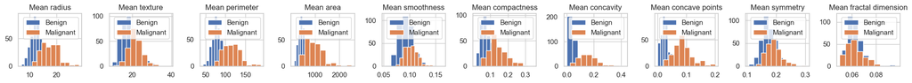

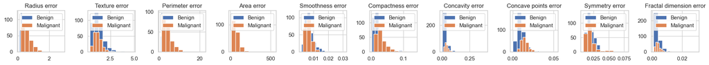

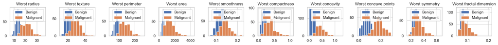

```python
# Creating figures
## Plotting histograms of the two populations for each feature
position = 1
fig1 = plt.figure(figsize = (20, 2))
for feature in df.iloc[:, 0:10]:
    figure_1 = plt.subplot(1, 10, position)
    plt.hist(df_benign[feature], label= 'Benign')
    plt.hist(df_malignant[feature], label= 'Malignant')
    plt.title(feature[0].capitalize())
    plt.legend()
    position += 1
    plt.tight_layout()

fig2 = plt.figure(figsize = (20, 2))
position = 1
for feature in df.iloc[:, 10:20]:
    figure_2 = plt.subplot(1, 10, position)
    plt.hist(df_benign[feature], label= 'Benign')
    plt.hist(df_malignant[feature], label= 'Malignant')
    plt.title(feature[0].capitalize())
    plt.legend()
    position += 1
    plt.tight_layout()

fig3 = plt.figure(figsize = (20, 2))
position = 1
for feature in df.iloc[:, 20:30]:
    figure_3 = plt.subplot(1, 10, position)
    plt.hist(df_benign[feature], label= 'Benign')
    plt.hist(df_malignant[feature], label= 'Malignant')
    plt.title(feature[0].capitalize())
    plt.legend()
    position += 1
    plt.tight_layout()

print("Three figures of ten subplots:")
```

1.6 Plot receiver-operating-characteristic (ROC) curves of the individual features into 3 figures, one figure for each of the groups of 10. The ROC curve of one feature can be calculated by moving a class decision threshold value across the value range of the feature.

```python
# Obtaining the three groups
mean = [df.columns[0:10]]
error = [df.columns[10:20]]
worst = [df.columns[20:30]]

# Cleaning the three groups from multi index lists to simple lists
mean_clean = []
error_clean = []
worst_clean = []


for x in range(0,9):
    for element in mean:
        mean_clean.append(element[x][0])
        position =+ 1


for x in range(0,9):
    for element in error:
        error_clean.append(element[x][0])

for x in range(0,9):
    for element in worst:
        worst_clean.append(element[x][0])

# Observing the lists are as required
print("Features relating to a mean:", mean_clean,"\n\nFeatures relating to an error:",error_clean,
      "\n\nFeatures relating to the worst value:", worst_clean)
```

```
Features relating to a mean: ['mean radius', 'mean texture', 'mean perimeter', 'mean area', 'mean smoothness', 'mean compactness', 'mean concavity', 'mean concave points', 'mean symmetry']

Features relating to an error: ['radius error', 'texture error', 'perimeter error', 'area error', 'smoothness error', 'compactness error', 'concavity error', 'concave points error', 'symmetry error']

Features relating to the worst value: ['worst radius', 'worst texture', 'worst perimeter', 'worst area', 'worst smoothness', 'worst compactness', 'worst concavity', 'worst concave points', 'worst symmetry']
```

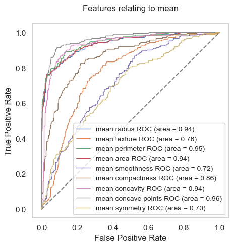

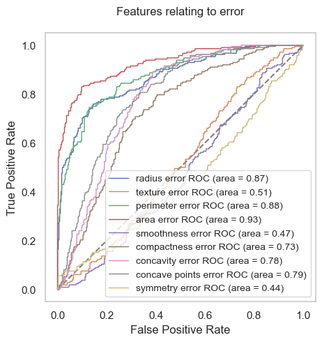

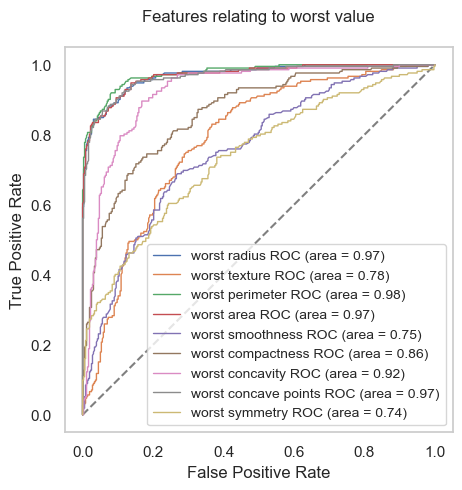

```python
# Producing the ROC curve for all features and presenting in three groups of 10
## Assigning variables
feature_groups = [mean_clean, error_clean, worst_clean]
titles = ["Features relating to mean", "Features relating to error", "Features relating to worst value"]
figure = 0
roc_auc_values = {}

## Creating figures, each to populate with 10 features
for group in feature_groups:
    plt.figure(figsize = (5,5))
    plt.title(titles[feature_groups.index(group)] +"\n")
    figure =+ 1
    plt.plot([0, 1], [0, 1], '--', color=('grey'))  # Adds the diagonal representing a feature with poor predictive power

    # Calculating values and plotting the ROC for each feature
    for feature in group:
        y_pred =  df[feature].values
        y_true = df.target.values.astype(int)

        fpr, tpr, thresholds = roc_curve(y_true, y_pred, pos_label = 0)

        # Storing the area under the curve for each feature
        roc_auc = metrics.auc(fpr, tpr)
        roc_auc_values[feature]=roc_auc

        # Plotting the value
        plt.plot(fpr, tpr, lw=1, label=feature +' ROC (area = %0.2f)' % (roc_auc))
        plt.xlim([-0.05, 1.05])
        plt.ylim([-0.05, 1.05])
        plt.grid()
        plt.xlabel('False Positive Rate')
        plt.ylabel('True Positive Rate')
        plt.legend(loc="best", fontsize = 10)
```

1.7 Which of the parameters seems promising based on the histograms and ROC curves? Justify your choice while referring to the particular features in the figures that indicate a good separation. Choose your top five candidate features.

**Answer**

Of the 10 nuclear features, the radius, perimeter, area, and concave points appear to meet the above requirements. However when it comes to the features needed for the model we need to be more specific. I'll take the five features above that produce the highest area under the ROC value:

```python
top_5 = dict(sorted(roc_auc_values.items(), key=lambda x: x[1], reverse = True))
top_5_listed = list(top_5.items())[:5]
print("The five features that best meet the criteria I've described are:")
for feature, value in top_5_listed:
    print(feature, "(",round(value, 3) ,")" )
```

```
The five features that best meet the criteria I've described are:
worst perimeter ( 0.975 )
worst radius ( 0.97 )
worst area ( 0.97 )
worst concave points ( 0.967 )
mean concave points ( 0.964 )
```

All of the above have good seperation between the two populations in the histograms as well so they are my selected five.

1.8 Split the data set into a training set (80%) and a test set (20%) using `train_test_split` in sklearn. The test data will not be used until the final evaluation.

```python
# Seperating the data into a reproducable training and test setm(random_state =10)
train_set, test_set = train_test_split(df,
                                       test_size = 0.2,
                                       train_size = 0.8,
                                       random_state = 10,
                                       shuffle = True)

print('Training set size:', train_set.shape)
print('Testing set size:', test_set.shape)
print('Check: training set percentage calcuated is:',  round(train_set.shape[0]/(train_set.shape[0]+test_set.shape[0]),2))
```

```
Training set size: (455, 31)
Testing set size: (114, 31)
Check: training set percentage calcuated is: 0.8
```

# 2 Train a regularised Stochastic Gradient Descent classifier

2.1 Create a stochastic gradient descent classifier object. Set the penalty to ’elasticnet’.

```python
SGD_model = SGDClassifier(penalty = 'elasticnet', random_state = 10)
SGD_model
```

```
SGDClassifier(penalty='elasticnet', random_state=10)
```

2.2 Explain in your own words what the parameter class_weight does. Set it to “balanced”.

**Answer**

```python
# Settng class_weight parameter
SGD_model.class_weight = 'balanced'
SGD_model
```

```
SGDClassifier(class_weight='balanced', penalty='elasticnet', random_state=10)
```

2.3 Explain in your own words what the parameter learning_rate does and how the learning rate will be adjusted using the selection ‘optimal’. Set it to ‘optimal’.

**Answer**

Learning_rate controls how quickly the model reaches convergence, or learns. The 'optimal' value aims to balance the convergence time and the accuracy. It uses the inital learning rate as a guide for consecutive iterations.

```python
# Setting learning_rate parameter
SGD_model.learning_rate = 'optimal'
SGD_model.learning_rate
```

```
'optimal'
```

2.4 Build a pipeline including a `StandardScaler` object and the classifier object. Question: Explain what the standard scaler does and what would happen if we would not scale the data with it.

```python
pipeline = make_pipeline(StandardScaler(),
                    SGD_model)
pipeline
```

```
Pipeline(steps=[('standardscaler', StandardScaler()),
                ('sgdclassifier',
                 SGDClassifier(class_weight='balanced', penalty='elasticnet',
                               random_state=10))])
```

**Answer**

The model interprets value magnitudes, not their relative differences. The standard scaler makes sure all the features are intepretted through the same lens, preventing any features from providing more or less weight than is reasonable relative to other features. This alteration converts values to z-scores (with the mean at 0 and standard deviation of 1). If this scaler isn't applied then features with larger values may take priority over other features and lead to a misinformed model.

2.5 Perform one grid search using five-fold cross validation (GridSearchCV) over values of alpha in the range of 0.001:0.001:0.1 and l1 ratio in the range of 0:0.1:1 using the training set.

```python
# Performing a grid search
param_grid = {'sgdclassifier__alpha': np.arange(0.001, 0.1, 0.001),
              'sgdclassifier__l1_ratio': np.arange(0, 1, 0.1)}
search = GridSearchCV(pipeline, param_grid, cv=5, return_train_score = True)
search
```

```
GridSearchCV(cv=5,
             estimator=Pipeline(steps=[('standardscaler', StandardScaler()),
                                       ('sgdclassifier',
                                        SGDClassifier(class_weight='balanced',
                                                      penalty='elasticnet',
                                                      random_state=10))]),
             param_grid={'sgdclassifier__alpha': array([0.001, 0.002, 0.003, 0.004, 0.005, 0.006, 0.007, 0.008, 0.009,
       0.01 , 0.011, 0.012, 0.013, 0.014, 0.015, 0.016, 0.017, 0.018,
       0.019, 0.02 , 0.021, 0.022, 0....
       0.055, 0.056, 0.057, 0.058, 0.059, 0.06 , 0.061, 0.062, 0.063,
       0.064, 0.065, 0.066, 0.067, 0.068, 0.069, 0.07 , 0.071, 0.072,
       0.073, 0.074, 0.075, 0.076, 0.077, 0.078, 0.079, 0.08 , 0.081,
       0.082, 0.083, 0.084, 0.085, 0.086, 0.087, 0.088, 0.089, 0.09 ,
       0.091, 0.092, 0.093, 0.094, 0.095, 0.096, 0.097, 0.098, 0.099]),
                         'sgdclassifier__l1_ratio': array([0. , 0.1, 0.2, 0.3, 0.4, 0.5, 0.6, 0.7, 0.8, 0.9])},
             return_train_score=True)
```

2.6 Display the mean test score (in attribute cv*results* under 'mean_test_score') of all hyper parameter combinations (alpha and l1 ratio) in colour-coded diagram with alpha on the x-axis and l1 ratio on the y-axis.

Describe in your own words the meaning of the alpha and l1 ratio and the hyper parameter value ranges that give high accuracy.

```python
# Seperating training data
train_set_features = train_set.iloc[:, :-1].copy()
train_set_response = train_set.iloc[:, -1:].copy()

# Fitting model to obtain test scores for various hyperparameter combinations
search.fit(train_set_features, train_set_response.to_numpy().ravel())
cv_results = pd.DataFrame(search.cv_results_)
mean_test_scores = cv_results[['param_sgdclassifier__alpha','param_sgdclassifier__l1_ratio','mean_test_score']]
mean_test_scores.head()
```

|  | param_sgdclassifier__alpha | param_sgdclassifier__l1_ratio | mean_test_score |
| --- | --- | --- | --- |
| 0 | 0.001 | 0.0 | 0.967033 |
| 1 | 0.001 | 0.1 | 0.975824 |
| 2 | 0.001 | 0.2 | 0.969231 |
| 3 | 0.001 | 0.3 | 0.973626 |
| 4 | 0.001 | 0.4 | 0.967033 |

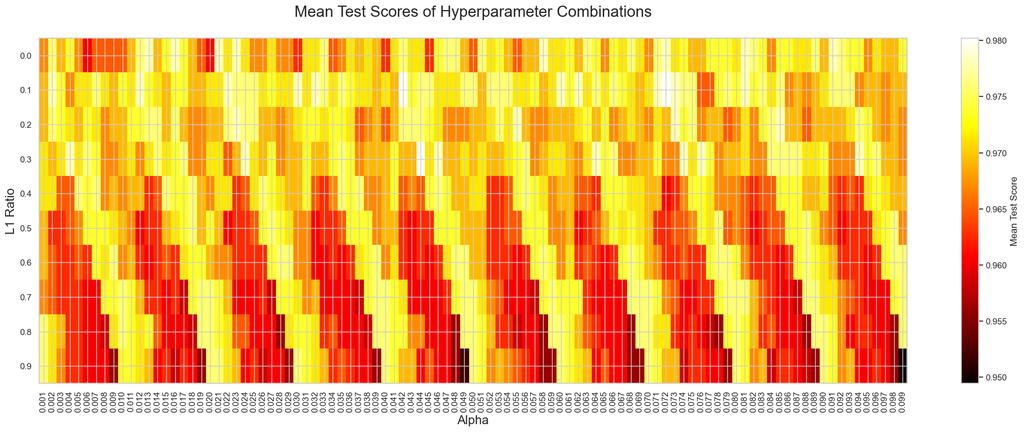

```python
# Producing a heat map to observe the three pieces of information
parameter_alpha = np.unique(mean_test_scores['param_sgdclassifier__alpha'].values)
parameter_l1_ratios = np.unique(mean_test_scores['param_sgdclassifier__l1_ratio'].values)
values_mean_test_scores = mean_test_scores['mean_test_score'].values.reshape(len(parameter_l1_ratios), len(parameter_alpha))

mean_scores_visual = plt.figure(figsize = [25, 8])
plt.imshow(values_mean_test_scores, cmap='hot', aspect='auto')
plt.colorbar(label='Mean Test Score')
plt.xticks(np.arange(len(parameter_alpha)), [f'{value:.3f}' for value in parameter_alpha], rotation=90)
plt.yticks(np.arange(len(parameter_l1_ratios)), [f'{value:.1f}' for value in parameter_l1_ratios])
plt.xlabel('Alpha', size = 16)
plt.ylabel('L1 Ratio', size = 16)
plt.title('Mean Test Scores of Hyperparameter Combinations\n', size = 20)
```

```python
print("The best parameter combinaton was:")
print("alpha = ", search.best_params_['sgdclassifier__alpha'])
print("L1_ratio = ", search.best_params_['sgdclassifier__l1_ratio'])
```

```
The best parameter combinaton was:
alpha =  0.015
L1_ratio =  0.0
```

```python
# Confiriming
mean_test_scores.sort_values('mean_test_score', ascending=False).head()
```

|  | param_sgdclassifier__alpha | param_sgdclassifier__l1_ratio | mean_test_score |
| --- | --- | --- | --- |
| 170 | 0.018 | 0.0 | 0.980220 |
| 340 | 0.035 | 0.0 | 0.980220 |
| 140 | 0.015 | 0.0 | 0.980220 |
| 179 | 0.018 | 0.9 | 0.978022 |
| 20 | 0.003 | 0.0 | 0.978022 |

The L1 ratio of 0.0 indicates a preference towards L2 regularization in which no features are set to 0. The alpha of 0.015 sits quite low in the range, indicating that the model is more optimal when it fits the training data more closely. note: I tried removing the shuffling of the trainning data but, although it changed the parameters, it made no differece to the outcome observed in the confusion matrix.

3.1 Take the best estimator from above. Calculate the confusion matrix, precision and recall of the final classifier using the test set. Based on these metrics, outline the chance of failing to detect a sample with cancer (malignant).

```
Precision =  1.0
Recall =  0.9733333333333334
```

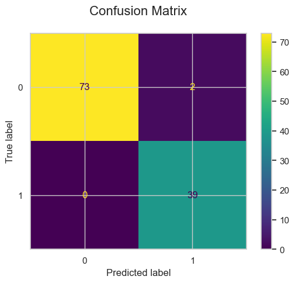

```python
# Fitting the test data
test_set_features = test_set.iloc[:, :-1].copy()
test_set_response = test_set.iloc[:, -1:].copy()
test_pred = search.predict(test_set_features)

# Compiling
outcome = test_set_features
outcome['target'] = test_set_response
outcome['pred'] = test_pred

# Calculating metric values
conf_matrix = confusion_matrix(outcome['target'], outcome['pred'], labels=[1,0])
cm = ConfusionMatrixDisplay(conf_matrix, display_labels = [0,1])
precision = precision_score(outcome['target'], outcome['pred'], labels=[1,0])
recall = recall_score(outcome['target'], outcome['pred'], labels=[1,0])

print("Precision = ", precision,"\nRecall = ", recall)
cm.plot()
plt.title("Confusion Matrix\n", size=16)
```

3.2 Display the coefficients for all features in descending order (largest first) in a list including the feature names.

Do the top features match your top 5 features chosen based on the ROC curves?

```python
# Determining coefficient values
## Obtaining features
feature_list  = []
for element in train_set_features.columns:
        feature_list.append(element[0])

## Obtaining Coefficients
coef_list = search.best_estimator_.named_steps.sgdclassifier.coef_

coef_df = pd.DataFrame({'Feature': feature_list,
                        'Coefficient': coef_list.tolist()[0]})

coef_df["Magnitude"] = np.abs(coef_df['Coefficient'])
top_5_coefficients = coef_df.sort_values("Magnitude", ascending=False).drop("Magnitude", axis=1).reset_index(drop = True)
top_5_coefficients.head(5)
```

|  | Feature | Coefficient |
| --- | --- | --- |
| 0 | worst texture | -0.616511 |
| 1 | radius error | -0.543862 |
| 2 | worst symmetry | -0.477208 |
| 3 | worst area | -0.424678 |
| 4 | worst radius | -0.416698 |

**Answer**

3.3 Select the 5 features with the strongest coefficients. Make a figure with 5x5 subplots, where each row and column corresponds to one of the 5 features and the subplots are the 2D scatterplots of the data set using the two features of that row and column. Unambiguously label True Positives, True Negatives, False Positives and False Negatives using marker types and/or colours.

```python
# Creating a Scatter Matrix
## Obtaining relevant data
top_5_features = top_5_coefficients['Feature'].head(5).tolist()
relevant_df = train_set_features[top_5_features]
relevant_df['target'] = train_set_response['target']
relevant_df['Pred'] = search.predict(train_set_features)
relevant_df['label'] = 0

for index, row in relevant_df.iterrows():
    if row['target'] == row['Pred']:
        if row['target'] == 0:
            relevant_df.at[index, 'label'] = 1#'tp'
        else:
            relevant_df.at[index, 'label'] = 2#'tn'
    elif row['target'] != row['Pred']:
        if row['target'] == 1:
            relevant_df.at[index, 'label'] = 3#'fp'
        else:
            relevant_df.at[index, 'label'] = 4#'fn'

colour = {'tp': 'green',
          'tn': 'darkgreen',
          'fp': 'red',
          'fn': 'orange'}

relevant_df['label'] = relevant_df['label'].astype(str)
relevant_df
```

[output not shown]

|  | worst texture | radius error | worst symmetry | worst area | worst radius | target | Pred | label |
| --- | --- | --- | --- | --- | --- | --- | --- | --- |
| 567 | 39.42 | 0.7260 | 0.4087 | 1821.0 | 25.74 | 0 | 0 | 1 |
| 295 | 16.93 | 0.2191 | 0.2823 | 661.1 | 14.67 | 1 | 1 | 2 |
| 91 | 25.84 | 0.3129 | 0.2556 | 830.9 | 16.43 | 0 | 0 | 1 |
| 1 | 23.41 | 0.5435 | 0.2750 | 1956.0 | 24.99 | 0 | 0 | 1 |
| 94 | 24.23 | 0.4768 | 0.2834 | 1025.0 | 18.23 | 0 | 0 | 1 |
| ... | ... | ... | ... | ... | ... | ... | ... | ... |
| 369 | 25.80 | 1.0080 | 0.2741 | 2227.0 | 27.66 | 0 | 0 | 1 |
| 320 | 20.61 | 0.3677 | 0.2608 | 390.4 | 11.28 | 1 | 1 | 2 |
| 527 | 19.27 | 0.1166 | 0.3110 | 564.9 | 13.61 | 1 | 1 | 2 |
| 125 | 23.58 | 0.2185 | 0.2364 | 725.9 | 15.49 | 1 | 1 | 2 |
| 265 | 47.16 | 1.1720 | 0.2868 | 3432.0 | 32.49 | 0 | 0 | 1 |

455 rows × 8 columns

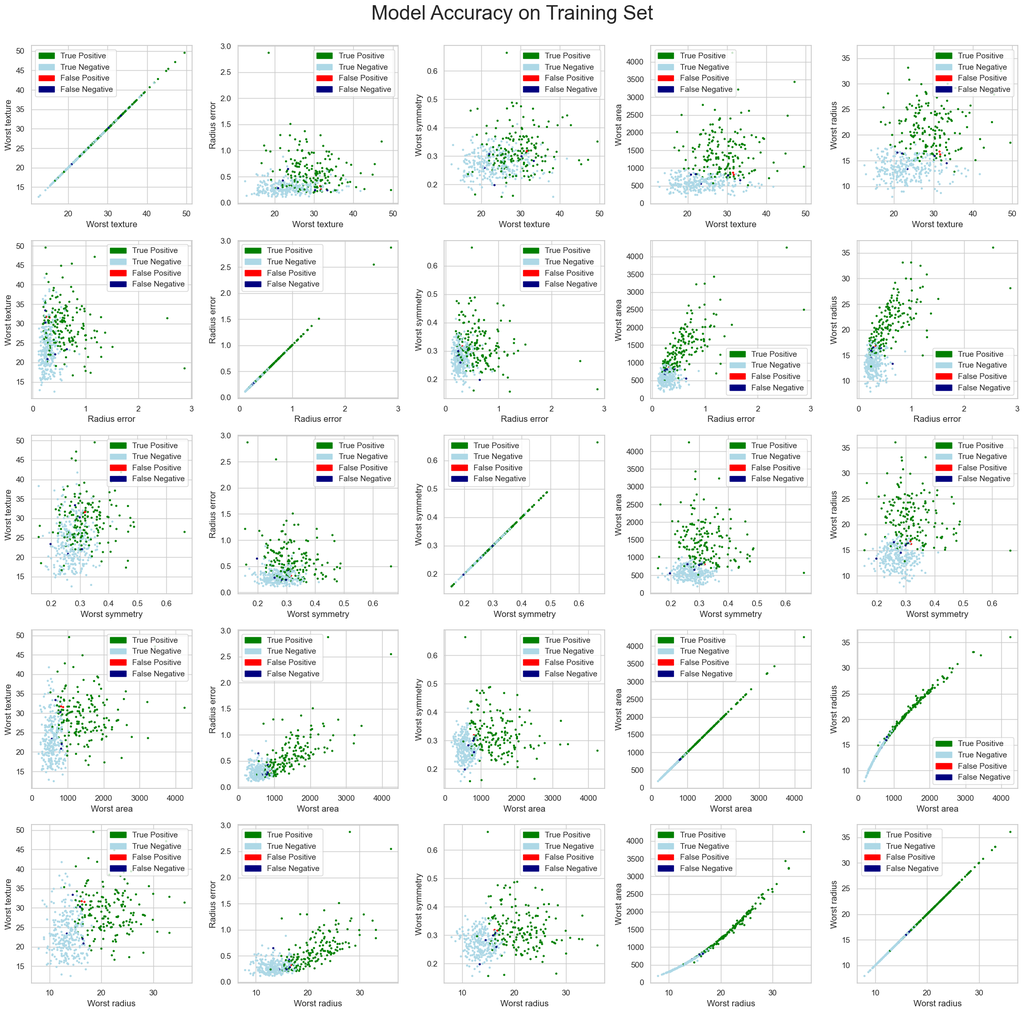

```python
## Creating Figure
scatter_matrix = plt.figure(figsize=(20, 20))
position = 1

for feature in relevant_df:
    if feature in relevant_df.iloc[:, 5:]:
        pass
    else:
        for x in relevant_df:
            if x in relevant_df.iloc[:, 5:]:
                pass
            else:
                plt.subplot(5, 5, position)
                plt.scatter(relevant_df[feature], relevant_df[x], s=4, c = relevant_df['label'],
                            cmap = mcolors.ListedColormap(['green','lightblue', 'red', 'navy']))
                plt.xlabel(feature[0].capitalize())
                plt.ylabel(x[0].capitalize())
                ## Creating legend
                tp = mpatches.Patch(color='green', label='True Positive')
                tn = mpatches.Patch(color='lightblue', label='True Negative')
                fp = mpatches.Patch(color='red', label='False Positive')
                fn = mpatches.Patch(color='navy', label='False Negative')
                plt.legend(handles = [tp,tn,fp,fn])

                position += 1
plt.suptitle("Model Accuracy on Training Set\n", size=28)
plt.tight_layout()
```

[figure not shown]

```python
# Assigning label
outcome['label'] = 0

for index, row in outcome.iterrows():
    if row['target'] == row['pred']:
        if row['target'] == 0:
            outcome.at[index, 'label'] = 1#'tp'
        else:
            outcome.at[index, 'label'] = 2#'tn'
    elif row['target'] != row['pred']:
        if row['target'] == 1:
            outcome.at[index, 'label'] = 3#'fp'
        else:
            outcome.at[index, 'label'] = 4#'fn'

## Creating Figure
scatter_matrix_test = plt.figure(figsize=(20, 20))
position = 1

for feature in outcome:
    if feature in outcome.iloc[:, 5:]:
        pass
    else:
        for x in outcome:
            if x in outcome.iloc[:, 5:]:
                pass
            else:
                plt.subplot(5, 5, position)
                plt.scatter(outcome[feature], outcome[x], s=4, c = outcome['label'],
                            cmap = mcolors.ListedColormap(['green','lightblue', 'red', 'navy']))
                plt.xlabel(feature[0].capitalize())
                plt.ylabel(x[0].capitalize())
                ## Creating legend
                tp = mpatches.Patch(color='green', label='True Positive')
                tn = mpatches.Patch(color='lightblue', label='True Negative')
                fp = mpatches.Patch(color='red', label='False Positive')
                fn = mpatches.Patch(color='navy', label='False Negative')
                plt.legend(handles = [tp,tn,fp,fn])

                position += 1
plt.suptitle("Model Accuracy on Test Set\n", size=28)
plt.tight_layout()
```

3.4 Summarise what can be seen in the 5x5 scatter plots. Do the two classes appear well separable and where can we see this in the plots? Is the classifier doing a good job and why?

**Answer**

3.5 Based on the 5x5 scatterplots, do you think the linear model is sufficient to separate the two classes, and why? Describe two advantages of using a linear model. Describe two advantages of using a more complex and flexible model, such as a Support Vector Machine (SVM).

**Answer**

The linear model is good because it can be easily explained and is computationally inexpensive compared to more advanced models. However a more complex model, such as an SVM, will have better accuracy as it can manage more complex or non-linear patterns in the data. They also have a variety of parameters surrounding the boundaries between classes which allows them to generalize well on unseen data.